# Wolverine Earnings Analysis

Volatility Around Earnings

Jacob Baier

November 13, 2018

## Volatility and Earnings

This is an analysis of equity volatility around earnings reports. In particular, we will address the following questions:

1. If the actual move after an earnings report is greater than or less than the market-implied expected move, what does this predict for realized volatility after the earnings report.
2. Is relationship #1 different when the actual move is a gain vs. loss.
3. Is the relationship in #1 different when stock price performance has been positive or negative in the run-up to the earnings report.
4. Is the relationship in #1 different when realized volatility has been high or low (relative to implied volatility) in the run-up to the earnings report?

### **Data & Methodology**

Term Definitions:

- **Move Ratio:**  
  To calculate move ratio we first removed the direction of change for each stock on a corresponding earnings day. We then simply divided by the expected move for that earnings day. This allowed us to both have a comparable measure regardless of stock and a comparison between the stocks’ actual perfomance vs expected performance.
- **SD #:**  
  SD in this analysis is simply short for standard deviation. We calculated 8 different SD metrics which we are using as measures of realized volatility. Specifically, our 8 SDs correspond to 4 different time windows both before and after the earnings date. That is, 3, 5, 7, and 10 days leading up to and after earnings. For reference, we are using negative days to refer to the lead up. So, SD 3 would be the standard deviation for the three days after earnings and SD -3 would be the same but for the three days leading up to earnings.
- **Return #:**  
  Return for our purposes are the stock movement over a number of days as compared to earnings days. In this case we used the same time intervals as SD, but only for the lead up to earnings instead of both (-3/-5/-7/-10). So Return -3, as we are calling it, would be the the stock movement for 3 days leading up to and earnings day.

### **Move-Ratio vs Subsequent Realized Volatility**

The following graph represents the “raw” data graphed at face value. Specifically, it is the expected move graphed against the 10 day standard deviations (SD 10). In order to make the graph more readable, however, each axis is scaled with a logarithm. As you can see the data is widely distributed in the y direction, and to a lesser extent in the x. This is in part due to the differing underlying prices that naturally have a large effect on the calculated standard deviations. Expected move varies to a lesser degree given that this is already a measure of SD. Having such a wide distribution will make it difficult to discern any concrete meaning from a graph given the amount of noise; this example is no exception. At first glance it is easy to see that there is indeed a positive correlation between the two. However, we cannot draw any conlcusions on if it is truely a correlation or a result of the noise.

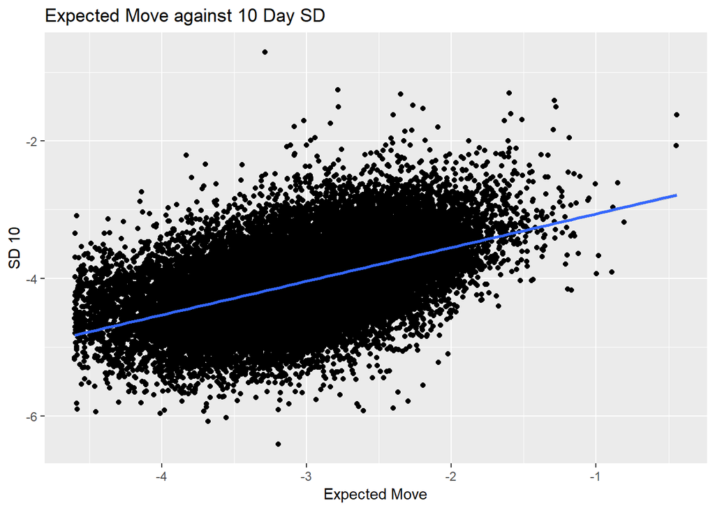

The next graph is the result of “cleaning up” the graphed data and the sacles of the plot. Here we are still listing standard deviation in the y direction, albeit modified, but now the x axis is move ratio instead of expected move. As described in the *Data & Methodology* section, move ratio is the actuale move scaled using the expected move. Here, however, we went one step further and cut the data into 100 equal width ranks. Given that there are more than 100 stocks present in the data, multiple stocks are represented by each rank. Separating the move ratios into discrete ranks allowed us to gather more readability out of a large amout of data. What this left us with was distinct veritcle lines of standard deviations corresponding to each rank.

On the y axis the standard deviation is also scaled using expected move, in order to create an equivalent scaled on both axes. We also applied a logarithm as stated before in addition to averaging on the “vertical lines” mentioned in the previous paragraph. By averaging these lines it allowed up to display only the center point of each line.

Finally, what we are left with is a graph with the noise removed. In addition, we can definitively say that there is a positive correlation between the move ratio and the standard deviation. The other three SD measures (3/7/10) are displayed in the appendix as each shows a similar relationship. In short, this graph details the fact that, yes a large move or “jump” will be followed by continued jumps. And naturally the opposite it true, if the volatility starts low, it its likely to stay low.

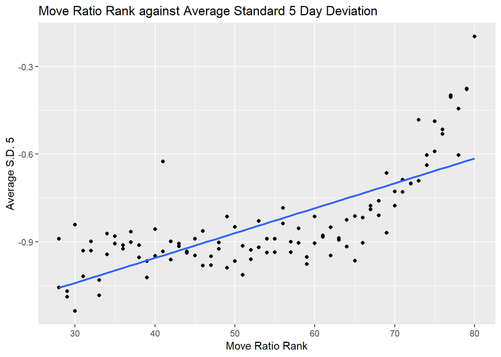

### **Gain vs Loss**

With a clear and readable graph the next step was to look at how the correlation might differ depending on whether there was a gain or loss on earnings day. Following is a similar looking graph as the previous section but split by the direction of the actual move on earnings day. As you can see both gain and loss have a similar shape to the data. The distinction between the two being that loss has a steeper fit; more positive correlation than gain. So, in essence, if a stock experiences a loss on earnings day, then it will followed by higher volatility and is more likely to experience a large move as time progreses than compared to a gain.

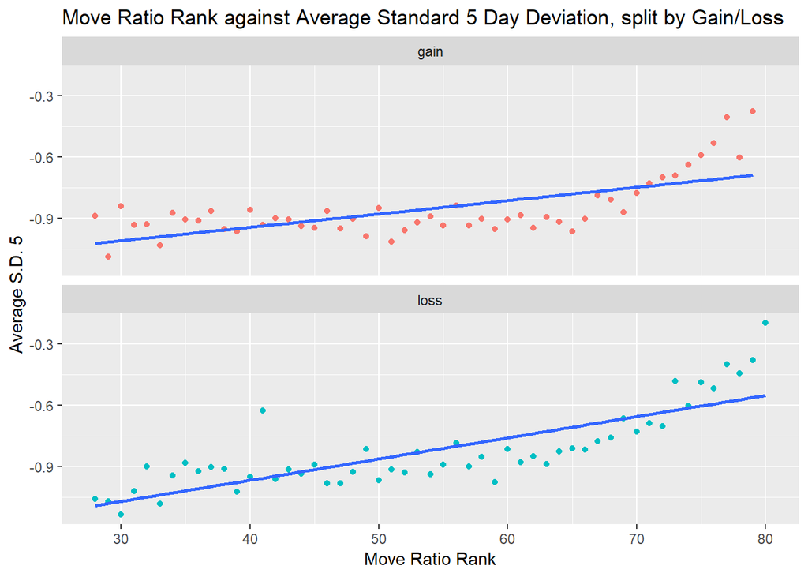

### **Positive and Negative Stock Performce Before Earnings**

The following sections analyze components leading up to earnings. Firstly,We analyzed the stock returns in a given window preceeding earnings and secondly did the same with volatility. The goal of these sections was to get a sense on how the stocks’ performance leading up to earnings might affect the results on earnings day and in the days following.

As mentioned, we calculated the returns for each stock in the time windows (-2,-3,-5,-7,-10 days) leading up to earnings; with the inclusion of -2 days. In order to perform a similar analysis to post earings, we again graphed the returns against *Move Ratio Rank*. For this section we chose to use the -2 returns; while all five graphs tend to be similar, the 2-day lead-up is close to earnings and would be the most descriptive of any trends there are due the proximity. As before, the remaining four graphs are located in the appendix.

Looking at *Move Ratio Rank against Lead-up Returns*, there are a few features that stand out. The primary feature is the linear grouping with small slope leading up to varying returns near the extreme. This tell us that the data is simply randomly distributed. Whereas, the rest of the data is nearly equivalent regardless of what move ratio was observed on earnings day. In short, this tells us that returns leading up to earnings has almost no correlation with the eventual observed move ratio. It is also worth noting that the linear fit is deflected upwards slightly by the large outliers near the extremes. This means that returns are, at best, a very mild predictor of volatility on earnings. However, this should in general only be considered true for events of high volatility leading up.

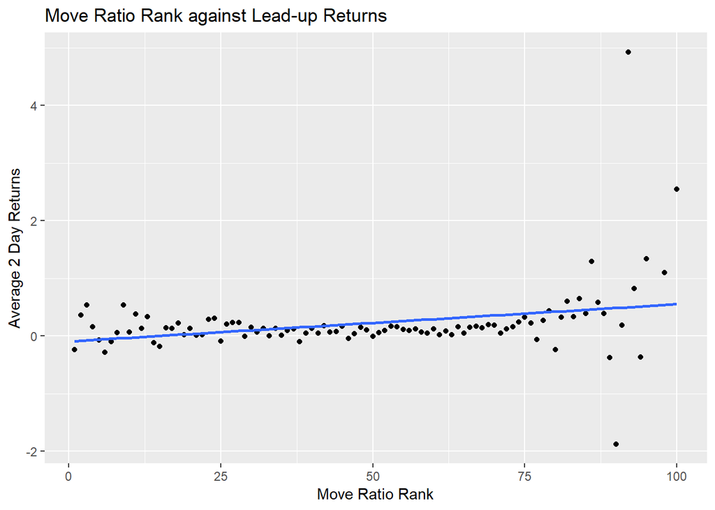

The second graph of this section is very similar as the graph *Move Ratio Rank against Average Standard 5 Day Deviation, split by Gain/Loss*. The key difference is that in the previous section, the gain/loss split was the direction of the stocks’ move on earings day. Whereas here we split via the direction of the stocks’ overall move for -5 day window. The same positive correlation exist here as it did for the earlier analysis. However, the difference in correlation between gain/loss is not present for lead up returns. Although, this shows similar volatility clustering, a loss leading up to earings will not further predict a jump as compared to a gain during lead up.

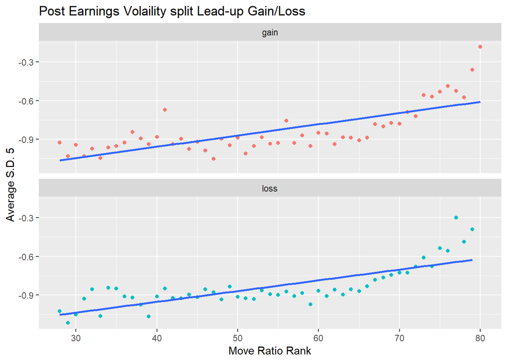

### **Price Volatility Before Earnings**

In a similar fashion to the *Move-Ratio vs Subsequent Realized Volatility* section, we compared the same Move Ratio Rank to the average standard deviation leading up to earnings day. Recall that the standard deviation for 5 days before we called S.D -5 as detailed in the *Terms and Definitions* section above. The graph included in this section is for the 5 day lead-up S.D whereas the other three graphs (-3/-7/-10) are again indcluded in the appendix.

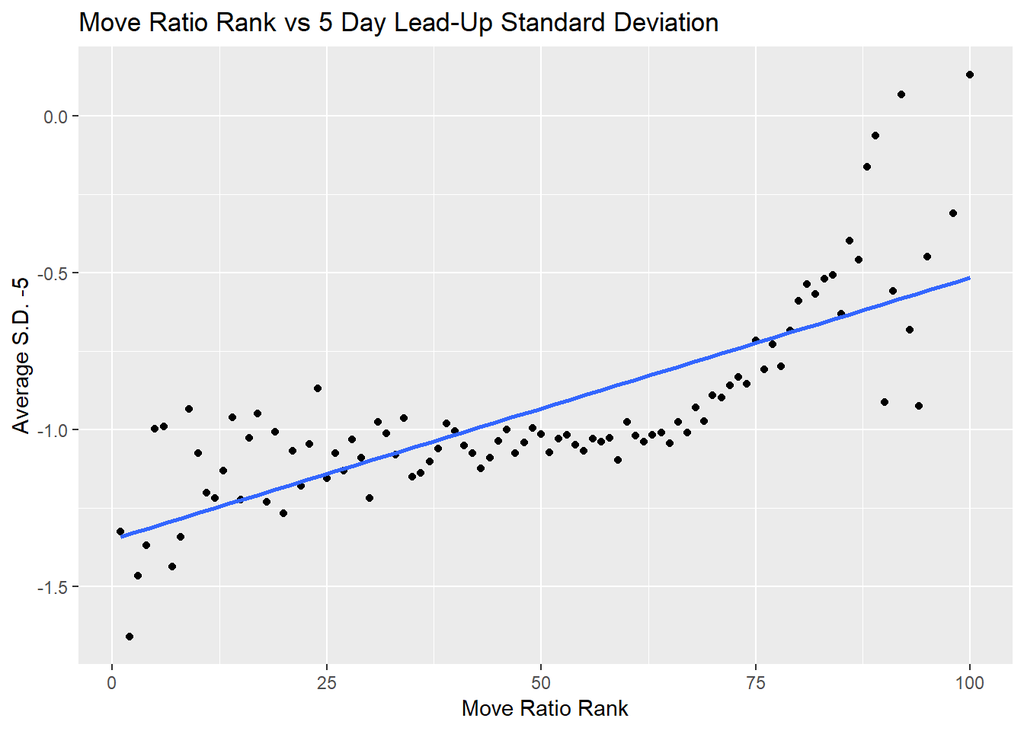

### **Next Steps**

For the most part, this analysis simply reveals the well-known phenomenon of volatility clustering: high volatility begets high volatility. However, our analysis isolates this around earnings dates, and also normalizes the notion of high volatility by market implied volatility. It is also worth noting, as previously stated, that the correlation more positive for loss vs. gain. Meaning large downward jumps are more strongly correlated with further jumps.

For further analysis, we would like to compare the current, and future, results against non-earnings data (a control group). Doing so will let us see that our findings do not hold outside of earnings and are indeed a result of the earnings release. Specifically, expected and actual move for non and earnings dates this will give us a baseline for what a pronounced or larger-than-normal jump is.

If possible, would you be able to send us non-earnings options data, so that we can analyze a control group and provide more thorough results?

### **Appendix**

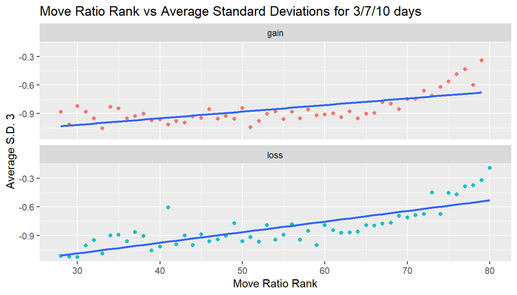

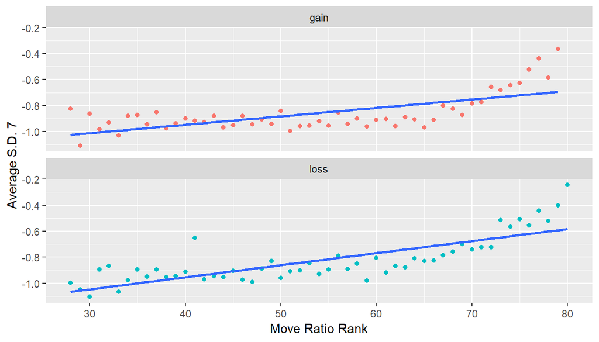

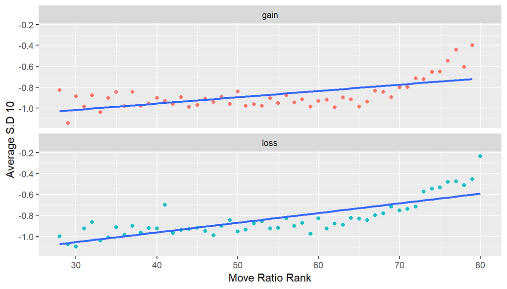

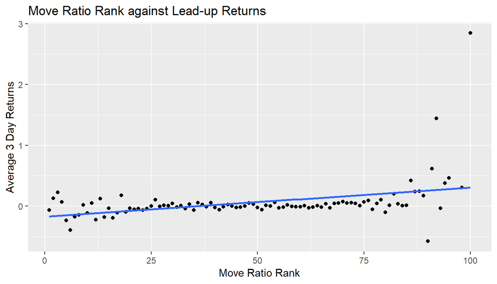

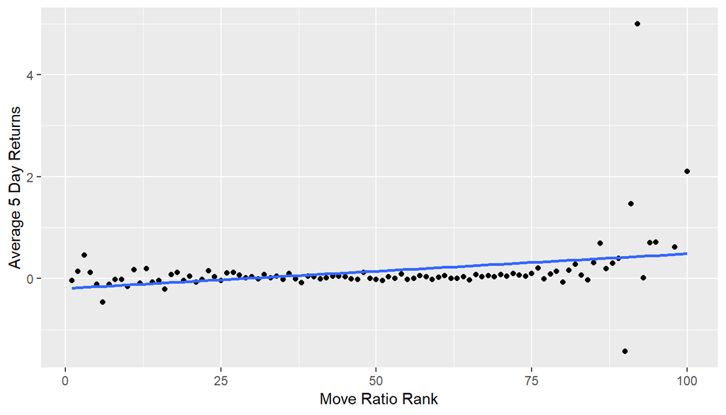

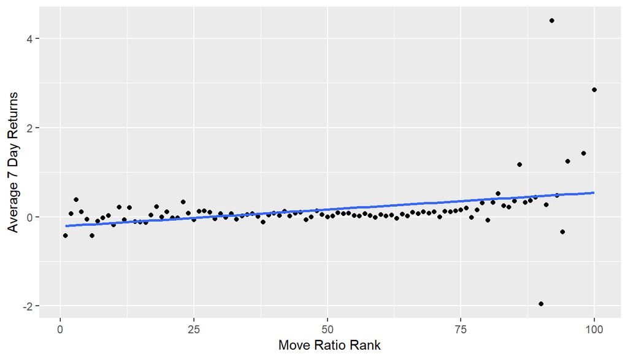

[figure not shown]

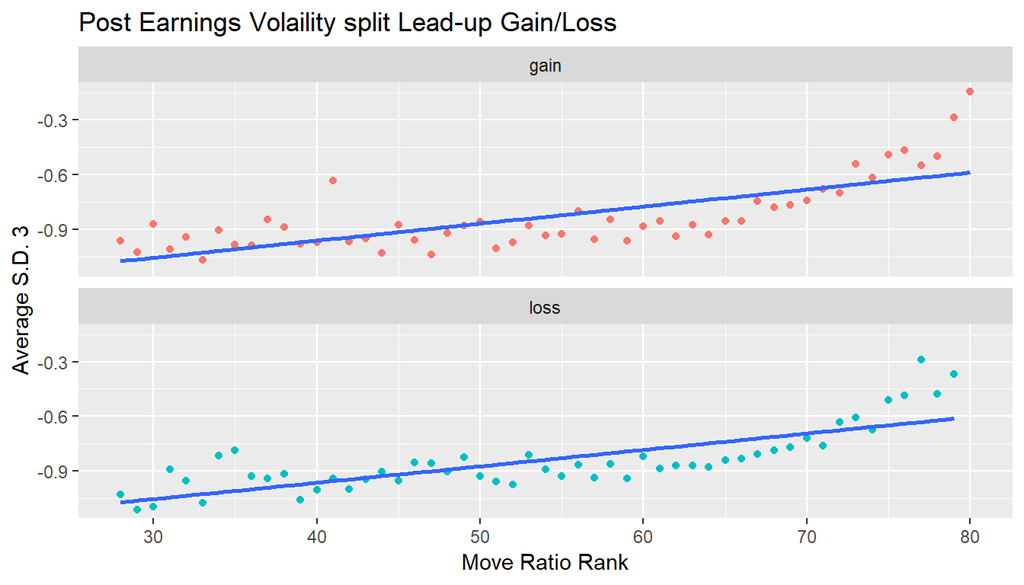

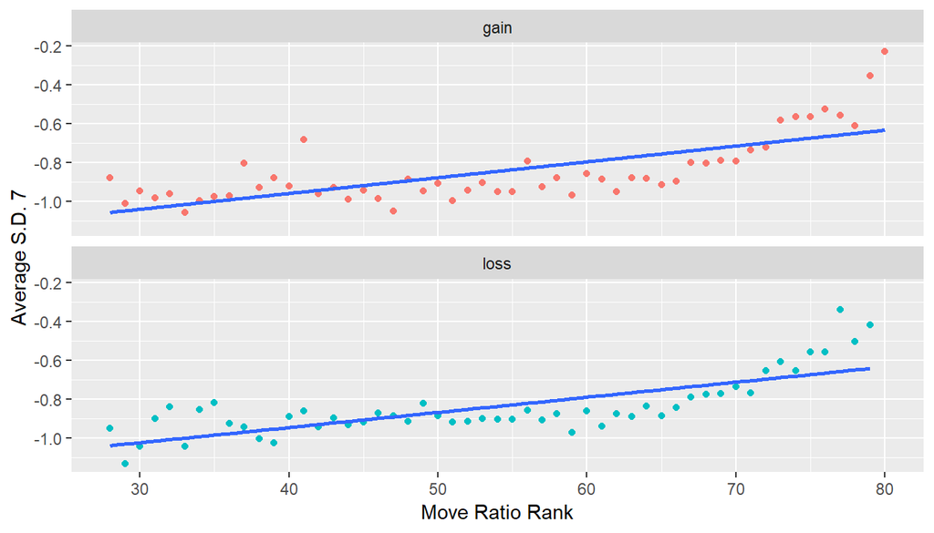

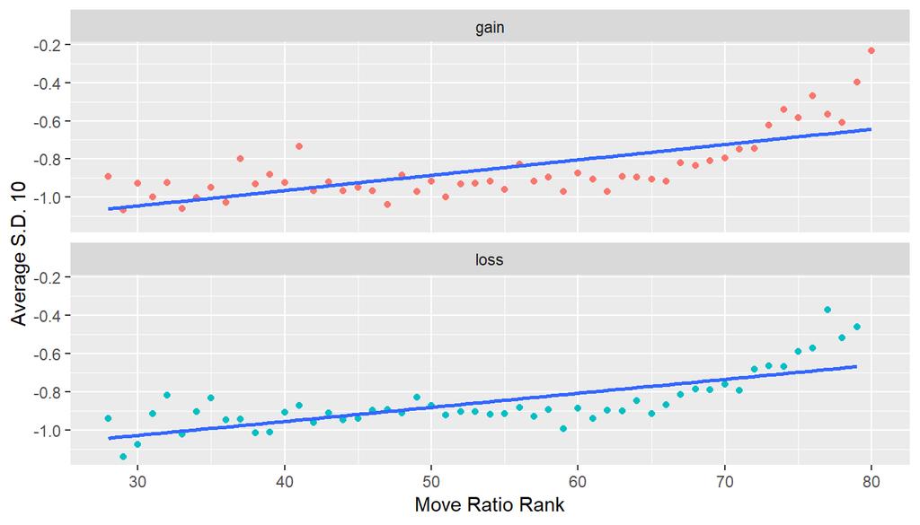

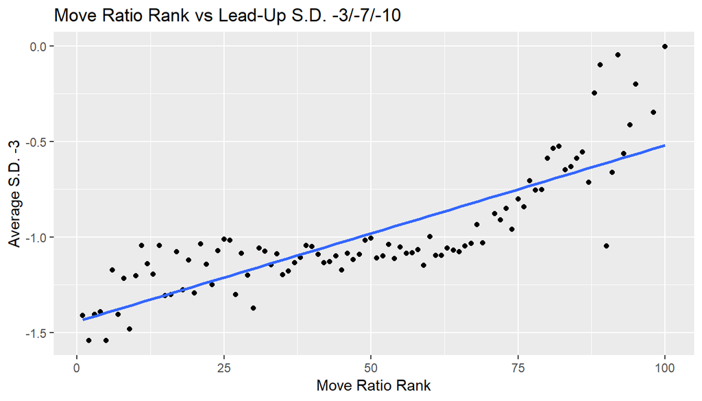

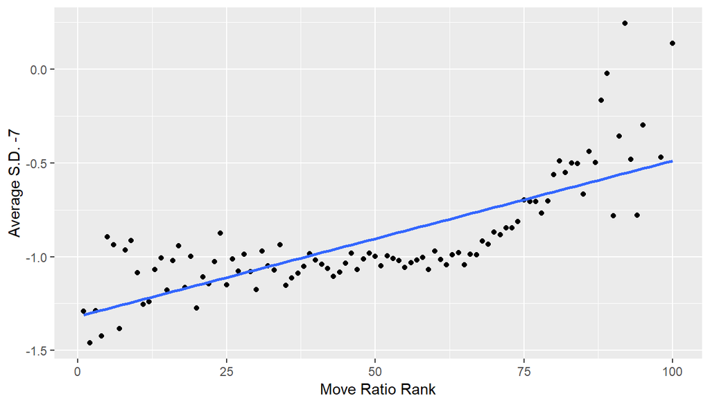

[1 more figures not shown]